# World Population

January 13, 2017

## Issues related to overpopulation

Fresh water: According to the UN 2.5% of the water on earth is fresh water, 70 percent of which is frozen. The remaining 30% is made up of rivers and lakes, many of which are polluted. It is estimated 0.003% of all waters is readily accessibly for human consumption. It estimated that by 2025 more than half of the world population will be facing water based vulerability.

Species Extinction: Climate change, habitat loss, pollution, overfishing and poaching are just a few of the effects of human beings.

## Issues related to overpopulation Continued

Global Warming: Global warming is a human caused phenomenon. The incraese in human population directly increases not only the amount of greenhouse gases released into the atmosphere, but also accelerated deforestation to create human habitats and land masses to feed the ever increasing population.

## Illustration

Below is a graph demonstrating the increase, and projected increase, of the world population. For an interactive version please click [here](https://razer20002.shinyapps.io/Data_Package_CW3/).

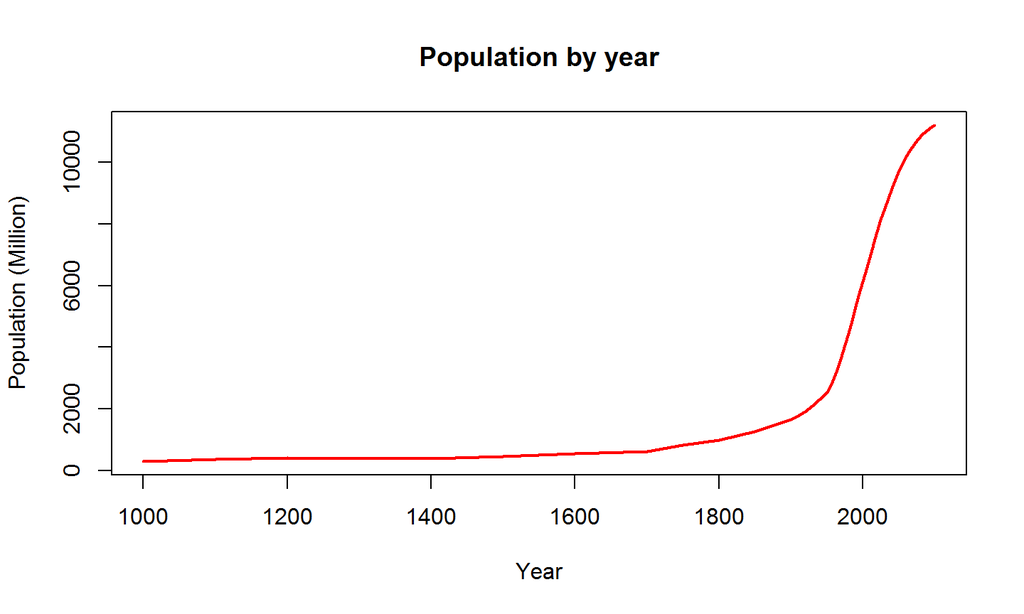